# **DaSL Collection**

Last Updated: June 06, 2025

# 1 About DaSL Collection

The mission of Data Science Lab Training Team is to: Empower people at Hutch and beyond with data literacy through training and community building to do more with data responsibly for health sciences.

Check out our:

- [General Courses](https://hutchdatascience.org/DaSL_Collection/general-courses.html)
- [Fred Hutch Online Learning](https://hutchdatascience.org/DaSL_Collection/fred-hutch-online-learning.html)
- [Our EdTech Software](https://hutchdatascience.org/DaSL_Collection/edtech-software.html)

You can also learn more about contributing [here](https://hutchdatascience.org/DaSL_Collection/faq.html).

# 2 General Courses

This collection of materials covers a wide range of data-related topics from introductory programming in R to specialized domains like genomics, environmental health, shared computing, version control, software development and more.

| Book Name | Funding | Description | Topics |
| --- | --- | --- | --- |
| AI for Decision Makers | Fred HutchITN | This set of four mini courses helps leaders make strategic decisions, drive innovation, enhance efficiency, and foster a culture that embraces the transformative power of these technologies. | ai, ai-tasks, audience-leaders, avoiding-harm, category-fundamentals-tools-resources, course, hutch-course, itn-course, launched-dec2023, policy, regulations, using-ai |
| AI for Efficient Programming | Fred HutchITN | This course on AI for software development explores the use of AI large language models (ChatGPT, Bard, etc) and their potential benefits and challenges. Hands-on activities show the ways in which AI … | ai-uses, annotate-code, artificial-intelligence, audience-researchers, audience-software-developers, category-software-dev, chatbot, course, ethics, hutch-course, itn-course, launched-apr2023, learn-a… |
| Adv Reproducibility in Cancer Informatics | ITN | This course introduces more advanced tools to increase the reproducibility of data analyses; building upon the Intro to Reproducibility course. GitHub, Docker, Code Review, and GitHub actions are disc… | audience-researchers, audience-software-developers, category-best-practices, code-review, course, docker, github, github-actions, itn-course, launched-jan2022, python, r, reproducibility, version-cont… |
| AnVIL: Epigenetics Intro | AnVIL | An introductory activity for epigenetics, or the idea of ""nature versus nurture"" in genetics. Learners use the UCSC Genome Browser. | anvil, course, epigenetics, human-genomes, module, ucsc-browser |
| AnVIL: Getting Started | AnVIL | A guide for getting started using AnVIL | anvil, cloud-computing, course, genomics, guide |
| AnVIL: Instructor Guide | AnVIL | A guide for instructors using AnVIL for workshops, lessons, or courses. | anvil, course, education, guide |
| AnVIL: WDL | AnVIL | Running and writing your first WDL workflow on AnVIL for absolute beginners. | anvil, course, genomics, module, wdl, workflows |
| AnVIL Data Subsetting | AnVIL | Tutorial for running the fastq_subsample WDL workflow on AnVIL! | anvil, course, genomics, module, wdl, wdl-workflow, workflow |
| AnVIL Demos | AnVIL | ⏱ 30-minute demos and tutorials from our live AnVIL series | anvil, cloud, cloud-computing, course, genomics, module, research |
| AnVIL Phylogenetic-Techniques | AnVIL | A semester-long course on the basics of molecular phylogenetic techniques | anvil, course, phylogenetics, r-programming |

[output cut: 38 more lines]

# 3 Fred Hutch Online Learning

This suite of online materials provide Fred Hutch researchers and data scientists with training on essential computational skills, as well as information how to use tools at the Hutch, such as the computing cluster.

| Book Name | Funding | Description | Topics |
| --- | --- | --- | --- |
| AI for Decision Makers | Fred HutchITN | This set of four mini courses helps leaders make strategic decisions, drive innovation, enhance efficiency, and foster a culture that embraces the transformative power of these technologies. | ai, ai-tasks, audience-leaders, avoiding-harm, category-fundamentals-tools-resources, course, hutch-course, itn-course, launched-dec2023, policy, regulations, using-ai |
| AI for Efficient Programming | Fred HutchITN | This course on AI for software development explores the use of AI large language models (ChatGPT, Bard, etc) and their potential benefits and challenges. Hands-on activities show the ways in which AI … | ai-uses, annotate-code, artificial-intelligence, audience-researchers, audience-software-developers, category-software-dev, chatbot, course, ethics, hutch-course, itn-course, launched-apr2023, learn-a… |
| Developing WDL Workflows | Fred Hutch | Developing WDL Workflows" shows a bioinformatics workflow developer how to strategically develop and scale up a WDL workflow that is iterative, reproducible, and efficient in terms of time and resourc… | hutch-course |
| FH Cluster 101 | Fred Hutch | This course introduces users to the Fred Hutch Cluster. It will lead users through account creation, using the terminal, connecting to the cluster, submitting jobs, and transferring files. Available i… | command-line, computing-cluster, course, hpcc, hutch-course |
| FH WDL101 Cromwell | Fred Hutch | An introduction to using Cromwell and WDL at the Fred Hutch | course, fredhutch, hutch-course, wdl |
| Intermediate-Git-GitHub | Fred Hutch | You will expand your current knowledge of Git and GitHub to help your research be more collaborative, reproducible, and transparent. | hutch-course |
| Intermediate R | Fred Hutch | The course continues building programming fundamentals in R programming and data analysis. You will learn how to make use of complex data structures, use custom functions built by other R users, creat… | hutch-course |
| Intro to Command Line | Fred Hutch | Fluency in programming and data science requires using computer software from the Command Line, a text-based way of controlling the computer. You will go on a guided under-the-hood tour behind the gra… | hutch-course |
| Intro to Python | Fred Hutch | The course covers fundamentals of Python, a high-level programming language, and use it to wrangle data for analysis and visualization. | hutch-course |
| Intro to R | Fred Hutch | The course covers fundamentals of R, a high-level programming language, and use it to wrangle data for analysis and visualization. The programming skills you will learn are transferable to learn more … | hutch-course |

[output cut: 3 more lines]

# 4 EdTech Software

The following are tools and software we’ve designed to make training more streamlined and reproducible. They have the `edtech-software` tag.

| Book Name | Funding | Description | Topics |
| --- | --- | --- | --- |
| AnVIL Collection | AnVILGDSCN | 📚 An auto-generating collection of all materials related to the AnVIL and GDSCN projects | anvil, content-library, edtech-software, gdscn, website |
| AnVIL Template | AnVIL | An OTTR spinoff template for creating AnVIL content | anvil, edtech-software, template |
| BioDIGSData | GDSCN | Data Package for BioDIGS Project | biodigs, edtech-software, gdscn |
| OTTR Template |  | OTTR for making courses! This is a template repo that helps people write 1 course but publish it in three places. Rendered example: https://jhudatascience.org/OTTR_Template/ | edtech-software, education, online-learning, open-source |
| OTTR Template Website |  | Template to create websites with checks for broken urls and spelling, as well as automated rendering. The rendered site can be found here: https://jhudatascience.org/OTTR_Template_Website/ | edtech-software |
| ari |  | :dancers: The Automated R Instructor | edtech-software |
| metricminer |  | R package that digs up data that matters from APIs, making it dashboard-ready | edtech-software |
| ottrpal |  | Tools for converting OTTR courses into Leanpub or Coursera courses :otter: | edtech-software |
| posterpoller |  | opensource polling system for poster competitions or other things! | edtech-software |
| text2speech |  | Text to Speech | edtech-software, speech-synthesis, text-to-speech, tts, voice |

[output cut: 1 more lines]

Check out our [FAQ](https://hutchdatascience.org/DaSL_Collection/faq.html) to learn how to contribute to the DaSL Collection. Learn about the authors [here](https://hutchdatascience.org/DaSL_Collection/about-the-authors.html).

# 5 FAQ

## 5.1 What is the DaSL Collection?

DaSL Collection uses the GitHub API to gather repositories that we have worked on. It renders the table in a markdown-readable format.

## 5.2 How can I add my new course/content to the Collection?

The following are needed to list your repository in the collection:

- Your repository must be created under the `jhudsl` or `fhdsl` organizations. For repositories under other organizations, you can fork the repository into the `jhudsl` or `fhdsl` organizations. [Example](https://github.com/fhdsl/Data-Wrangling)
- Your repository “code” tab must have a **description**, **homepage**, and **topic tags** filled out in the “About” section on the right-hand side.
- Your repository must be set to **public**.
- Your repository must have at least one of three tags: `course` (general purpose courses), `hutch-course` (Fred Hutch specific courses), or `edtech-software`. If you feel there is another applicable category that should be listed, please reach out to [Ava](https://github.com/avahoffman).

## 5.3 How often is the Collection updated?

The collection is rendered on Sundays between 3am and 5am EST.

## 5.4 I want to use the raw Collection data!

You can use the following link:

<`https://raw.githubusercontent.com/fhdsl/DaSL_Collection/main/resources/collection.tsv`>

## 5.5 How do I edit **description**, **homepage**, and **topics**?

### 5.5.1 Where to edit

Start by clicking the gear button on the top right of the repository page on GitHub next to “About”.

[figure not shown]

Where is the `gear` button next to the “About” menu?

### 5.5.2 Edit repository description

Enter a concise description, for example “A guide for instructors using AnVIL for workshops, lessons, or courses.”

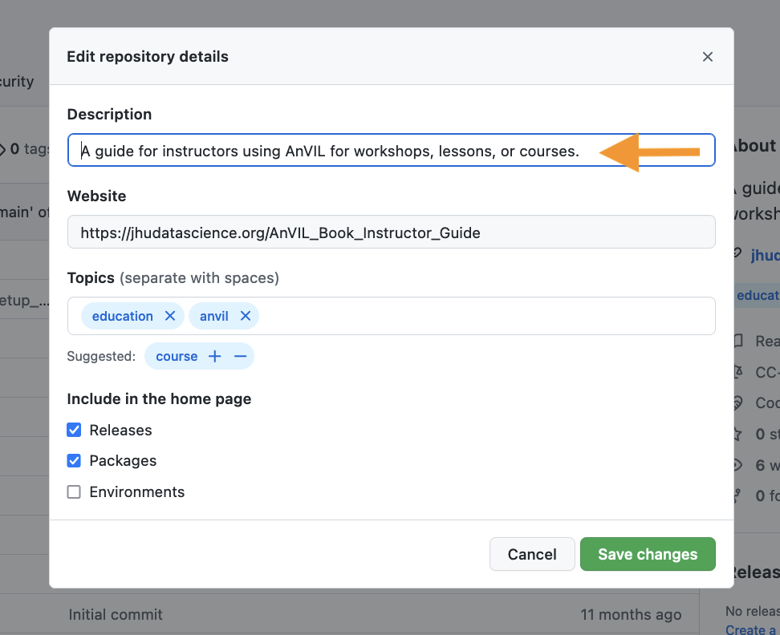

Add a description to the repository.

### 5.5.3 Edit repository homepage

Make sure you link to the website where your course is being rendered. For example, this repository links to https://jhudatascience.org/AnVIL_Book_Instructor_Guide.

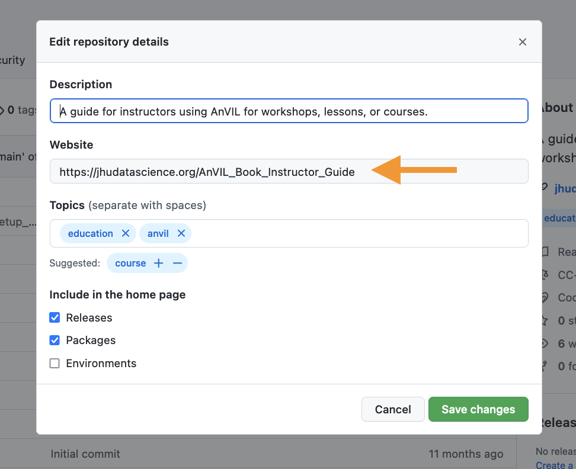

Add a homepage link to the repository.

### 5.5.4 Edit repository topics

Finally, you should add any relevant topics, as they will be listed in the Collection table!

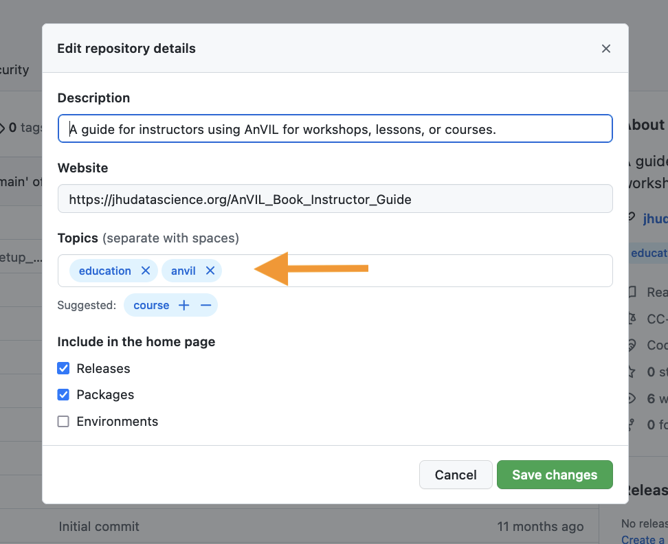

Add tags to the repository.

# About the Authors

These credits are based on our [course contributors table guidelines](https://github.com/jhudsl/OTTR_Template/wiki/How-to-give-credits).

| Credits | Names |
| --- | --- |
| **Technical** |  |
| Course Publishing Engineer and Maintainer | [Ava Hoffman](https://www.avahoffman.com/) |
| Template Publishing Engineers | [Candace Savonen](https://www.cansavvy.com/), [Carrie Wright](https://carriewright11.github.io/) |
| Publishing Maintenance Engineer | [Candace Savonen](https://www.cansavvy.com/) |
| Technical Publishing Stylists | [Carrie Wright](https://carriewright11.github.io/), [Candace Savonen](https://www.cansavvy.com/) |
| Package Developers (ottrpal) | [John Muschelli](https://johnmuschelli.com/), [Candace Savonen](https://www.cansavvy.com/), [Carrie Wright](https://carriewright11.github.io/) |